# Übung 3

# Aufgabe 2 (Predicting Baseball Salaries)

**[7 points]** Für diese Frage werden wir das `Gehalt` von `Hitters` vorhersagen. (`Hitters` ist auch der Name des Datensatzes.) Wir entfernen zuerst die fehlenden Daten:

```r
library(ISLR)
Hitters = na.omit(Hitters)
```

Nachdem du `uin` auf Ihre StudentID umgestellt hast, verwende den folgenden Code, um die Daten aufzuteilen.

```r
uin = 1910837830
set.seed(uin)
hit_split = initial_split(Hitters, p = 0.6, list = FALSE)
hit_trn = hit_split %>% training()
hit_tst = hit_split %>% testing()
```

Gehen wie folgt vor:

- Tunen Sie ein verstärktes Baummodell mit dem folgenden Tuning-Grid und der 5-fachen Kreuzvalidierung.

```r
gbm_grid = expand.grid(interaction.depth = c(1, 2),
                       n.trees = c(500, 1000, 1500),
                       shrinkage = c(0.001, 0.01, 0.1),
                       n.minobsinnode = 10)
```

- Tunen Sie einen Random Forest mit OOB Resampling und **allen** möglichen Werte von `mtry`.

Erstellen Sie eine Tabelle, in der die Ergebnisse von drei Modellen zusammengefasst sind:

- Tuned boosted tree Model
- Tuned random forest Model
- Bagged tree Model

Für jedes, Berichte:

- Resampled RMSE
- Test RMSE

```r
#tuned boosted tree Model
tuned_boosted_tree = train(Salary ~ ., data = hit_trn,
                method = "gbm",
                trControl = cv_5,
                verbose = FALSE,
                tuneGrid = gbm_grid)

#Tuned Random Forest Model
rf_grid = rf_grid = expand.grid(mtry = 1:(ncol(hit_trn) - 1))
tuned_rf  = train(Salary ~ ., data = hit_trn,
                method = "rf",
                trControl = oob,
                tuneGrid = rf_grid)

#Bagged Tree
bagged_tree = train(Salary ~ ., data = hit_trn,
                method = "rf",
                trControl = oob,
                tuneGrid = data.frame(mtry = (ncol(hit_trn) - 1)))


#Calc RMSE
calc_rmse = function(actual, predicted) {
  sqrt(mean((actual - predicted) ^ 2))
}

tbt_rmse_trn = calc_rmse(predicted = predict(tuned_boosted_tree, hit_trn),
                         actual = hit_trn$Salary)

rf_rmse_trn = calc_rmse(predicted = predict(tuned_rf, hit_trn),
                        actual = hit_trn$Salary)

bt_rmse_trn = calc_rmse(predicted = predict(bagged_tree, hit_trn),
                        actual = hit_trn$Salary)

tbt_rmse_tst = calc_rmse(predicted = predict(tuned_boosted_tree, hit_tst),
                         actual= hit_tst$Salary)

rf_rmse_tst = calc_rmse(predicted = predict(tuned_rf, hit_tst),
                        actual = hit_tst$Salary)

bt_rmse_tst = calc_rmse(predicted = predict(bagged_tree, hit_tst),
                        actual = hit_tst$Salary)

result_2 <- tribble(~model, ~train_rmse, ~test_rmse,
                    "Tuned boosted tree Model", tbt_rmse_trn, tbt_rmse_tst,
                    "Tuned random forest Model", rf_rmse_trn, rf_rmse_tst,
                    "Bagged tree Model", bt_rmse_tst, bt_rmse_tst)
result_2
```

| model | train_rmse | test_rmse |
| --- | --- | --- |
| Tuned boosted tree Model | 235.9489 | 293.4324 |
| Tuned random forest Model | 124.2192 | 287.2835 |
| Bagged tree Model | 297.6596 | 297.6596 |

# Aufgabe 3 (Transforming der Response)

**[5 points]** Dann fahren wir mit den Daten aus Übung 2 fort. Das Buch, ISL, schlägt vor, die Response “Salary”, log-transformieren, bevor es in einen Random Forest passt. Ist das notwendig? Tunen Sie einen Random Forest neu, wie Sie es in Übung 2 getan haben, außer mit einer logarithmisch transformierten Response. Berichten Sie den Test RMSE sowohl für das nicht transformierte als auch für das transformierte Modell im Originalmaßstab der Antwortvariablen.

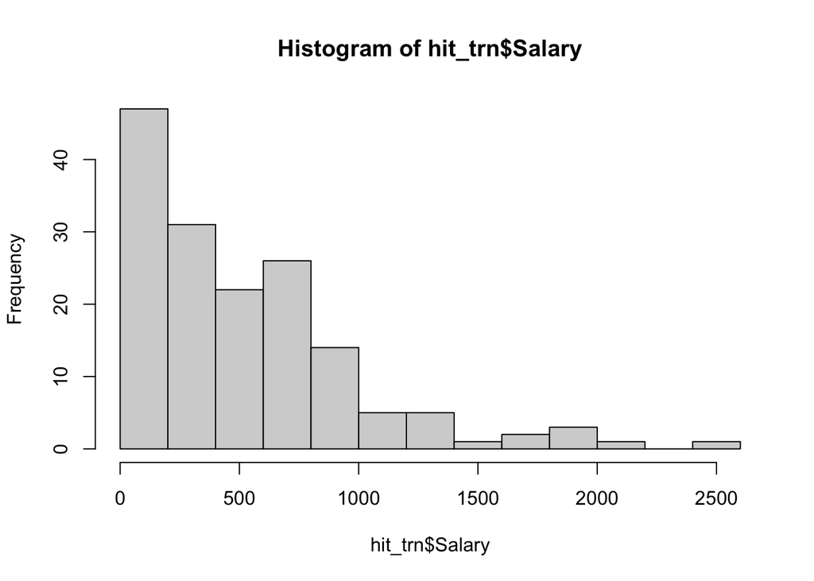

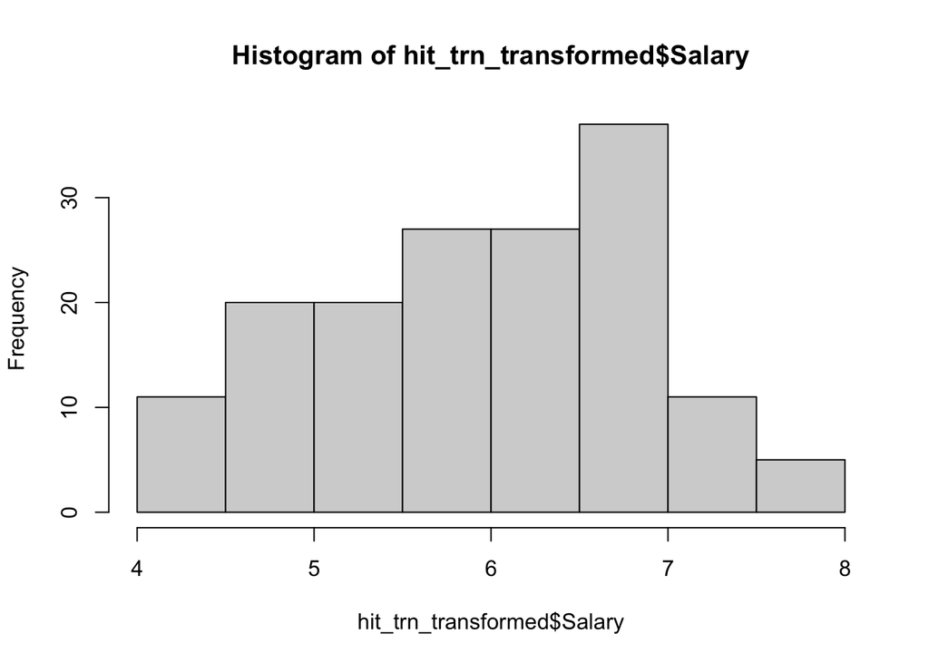

```r
rf_grid = expand.grid(mtry = 1:(ncol(hit_trn_transformed) - 1))

transformed_rf  = train(Salary ~ ., data = hit_trn,
                        method = "rf",
                        trControl = oob,
                        tuneGrid = rf_grid)

transformed_rf_transformed  = train(Salary ~ ., data = hit_trn_transformed,
                        method = "rf",
                        trControl = oob,
                        tuneGrid = rf_grid)

#Calc RMSE
rmse_rf_hit_tst = calc_rmse(predicted = predict(transformed_rf, hit_tst),
                        actual = hit_tst$Salary)

rmse_rf_hit_tst_transformed = calc_rmse(predicted = predict(transformed_rf_transformed, hit_tst_transformed),
                         actual= hit_tst_transformed$Salary)


transformed_rf
```

```
## Random Forest
##
## 158 samples
##  19 predictor
##
## No pre-processing
## Resampling results across tuning parameters:
##
##   mtry  RMSE      Rsquared
##    1    302.8529  0.5546009
##    2    283.5253  0.6096361
##    3    284.9990  0.6055676
##    4    289.4131  0.5932549
##    5    281.6905  0.6146722
##    6    285.0895  0.6053171
##    7    286.1638  0.6023370
##    8    287.3098  0.5991454
##    9    285.1180  0.6052380
##   10    288.0166  0.5971709
##   11    289.0978  0.5941408
##   12    286.7074  0.6008247
##   13    289.7768  0.5922319
##   14    290.0470  0.5914712
##   15    285.7289  0.6035446
##   16    289.5416  0.5928937
##   17    286.3854  0.6017208
##   18    286.7654  0.6006630
##   19    286.1302  0.6024303
##
## RMSE was used to select the optimal model using the smallest value.
## The final value used for the model was mtry = 5.
```

```r
result_3 <- tribble(~model, ~test_rmse_base, ~test_rmse_log,
                    "Log Transformed Random Forrest", rmse_rf_hit_tst, rmse_rf_hit_tst_transformed)
result_3
```

| model | test_rmse_base | test_rmse_log |
| --- | --- | --- |
| Log Transformed Random Forrest | 289.018 | 0.3948737 |

# Aufgabe 4 (Concept Checks)

**[1 point each]** Beantworte die folgenden Fragen auf der Grundlage deiner Ergebnisse aus den drei Übungen.

**(a)** Vergleichen Sie die Zeit, die für die Abstimmung der einzelnen Modelle benötigt wird. Ist der Unterschied zwischen dem OOB- und dem CV-Ergebnis für den Random Forest ähnlich, wie Sie es erwartet hätten? Das OOB-Ergebnis ist deutlich schneller als die CV. Einerseits weil die Cross-Validation mehrmals über den Datensatz iteriert und zweitens, weil beide Funktionen unterschiedliche Defaults setzen wie sie die Daten bearbeiten (https://stats.stackexchange.com/questions/198839/evaluate-random-forest-oob-vs-cv/199201)

**(b)** Vergleiche den getunten Wert von `mtry` für jeden der getunten Random Forests. Wählen sie das gleiche Modell? Für beide RFs wurde jeweils 1 als Wert für mtry verwendet. Sie wählen also somit das gleiche Modell.

### Salary

**(e)** Erzeuge einen Plot, der die Tuningergebnisse für das Tuning des boosted tree model anzeigt.

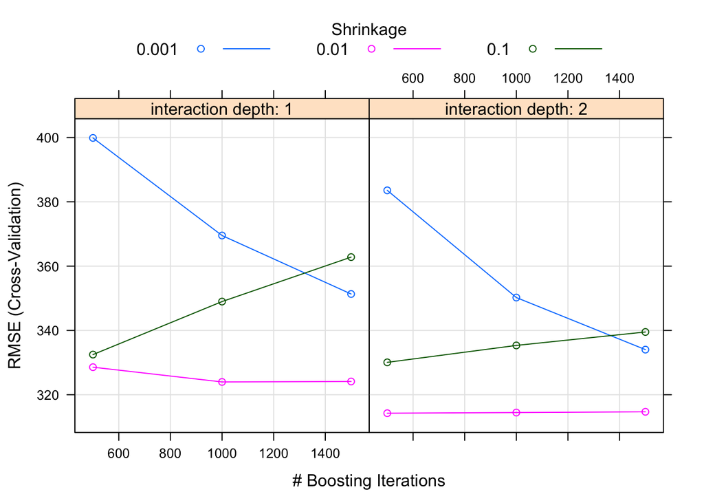

```r
plot(tuned_boosted_tree)
```

**(f)** Erzeuge einen Plot der Variable Importance für den tuned Random Forest.

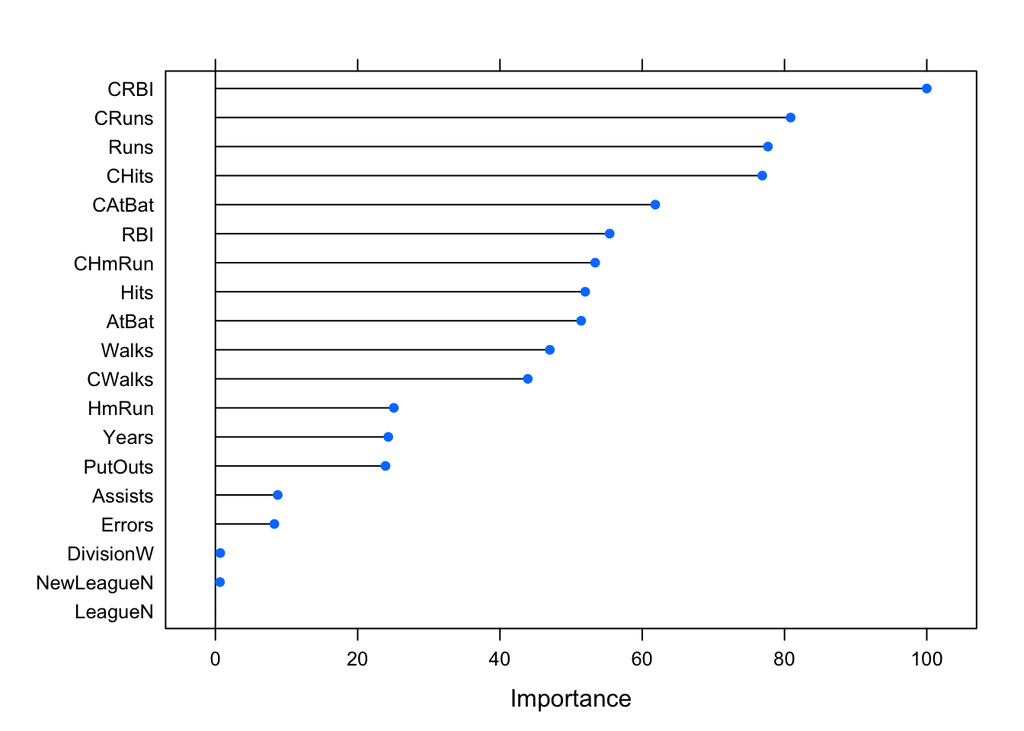

```r
plot(varImp(tuned_rf))
```

**(g)** Erzeuge einen Plot der Variable Importance für das tuned Boosted Tree Model.

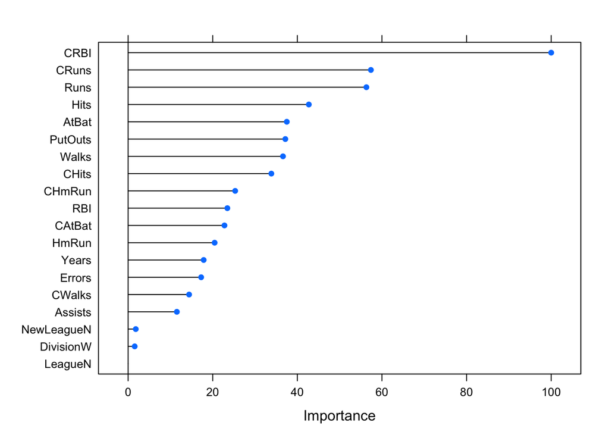

```r
plot(varImp(tuned_boosted_tree))
```

**(h)** Nach dem Random Forest, was sind die drei wichtigsten Prädiktoren?

```r
names(importance(tuned_rf$finalModel)[order(importance(tuned_rf$finalModel), decreasing = TRUE), ][1:3])
```

```
## [1] "CRBI"  "CRuns" "Runs"
```

**(i)** Nach dem Boosted Model, was sind die drei wichtigsten Prädiktoren?

```r
rownames(varImp(tuned_boosted_tree)$importance)[order(varImp(tuned_boosted_tree)$importance$Overall, decreasing = TRUE)][1:3]
```

```
## [1] "CRBI"  "CRuns" "Runs"
```